# Generating a travel time matrix

The r5r package is useful for calculating travel time matrices for car, transit, bicycle, and pedestrian trips. You can use a travel time matrix as a starting point for finding the travel time to the closest point or for generating isochrones.

# Required packages

This example uses the following packages. Before loading the r5r package, you should run the line `options(java.parameters = '-Xmx2G')` to allocate enough memory to Java (which r5r will use in the background).

```r
options(java.parameters = '-Xmx2G')

library(tidyverse)
library(sf)
library(r5r)
library(ggspatial)
library(ggthemes)
library(knitr)
```

# Load some sample data

I’ll start with two sets of points for Somerville, Massachusettets: polling locations and transit stops (including those within half a mile of the city’s boundary).

Here they are on a quick static map:

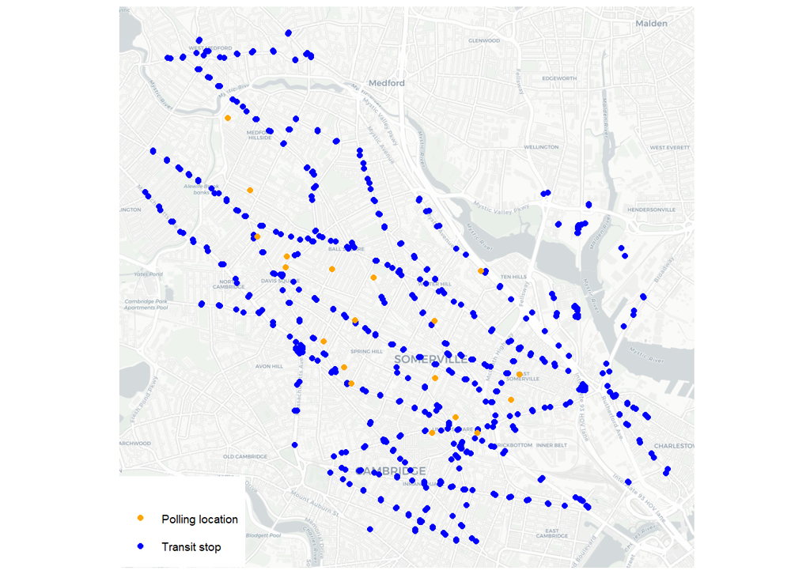

```r
ggplot() +
  annotation_map_tile(type = "cartolight", zoomin = 0) +
  geom_sf(data = transit,
          aes(color = "Transit stop")) +
  geom_sf(data = polls,
          aes(color = "Polling location")) +
  scale_color_manual(name = "",
                     values = c("orange","blue")) +
  theme_map()
```

# Set up networks and R5 core

For r5r to calculate travel times, I need to have a folder within my project directory with street network data. This needs to be OpenStreetMap data with a .pbf extension. You can download the data in the format you need from [extract.bbbike.org](https://extract.bbbike.org/). You may want to watch [this video on how to get data through the BBBike web interface](https://harvard.zoom.us/rec/play/gUcKA268dHZcjD5qJX0MJmWlT4IpZ6dVnxZ2jFks-Y19irF2C5PFsHz4yL2EBBTHuu1Ua1HVXDArlqtz.mheNs6bxuHt9O29S?autoplay=true&startTime=1664806470000).

If you want to calculate transit travel times, you’ll need to save a GTFS file (with a .zip extension) to the network folder as well.

Now, you can set up an R5 core that will use all the data (street data and any transit data) in the directory you specify. In this case, I’m using a directory I’ve called “networks.” You’ll get a lot of warnings and messages. Don’t panic. You can probably ignore them, as long as you end up with a network.dat file in your networks folder that has a file size of more than zero.

```r
my_core <- here("a5-files",
                "Examples",
                "networks") %>%
  setup_r5(verbose = FALSE)
```

# Prepare point layers

The `r5r` package will find travel times between point layers. The data must be in the WGS 84 coordinate reference system and must have a data column called “id”. If you already have an ID column of some kind, you can rename it as “id”. You can also create an ID column of sequential numbers.

```r
polls <- polls %>%
  st_transform("WGS84") %>%
  mutate(id = seq(1, length(polls$geometry), by = 1))

transit <- transit %>%
  st_transform("WGS84") %>%
  rename(id = stop_id)
```

# Generate a travel time matrix

Now I can generate a travel time matrix. I can choose among four modes: `WALK`, `BIKE`, `CAR`, or `TRANSIT`. I didn’t include transit data when I created my network (and calculating transit directions to the closest transit stop doesn’t make a lot of sense), so I can’t use that in this case. I’ll USE `mode = "WALK"`.

```r
walk_to_polls <- travel_time_matrix(my_core,
                                   origins = transit,
                                   destinations = polls,
                                   mode = "WALK")
```

This will generate a data frame with three columns:

- `fromId` with the ID of an origin point,
- `toId` with the ID of a destination point, and
- `travel_time` with the travel time in minutes between those two points.

```r
head(walk_to_polls) %>%
  kable()
```

| fromId | toId | travel_time |
| --- | --- | --- |
| 106 | 1 | 69 |
| 106 | 2 | 34 |
| 106 | 3 | 66 |
| 106 | 4 | 73 |
| 106 | 5 | 66 |
| 106 | 6 | 38 |

# Stop the R5 core

Remember to stop the R5 core when you’re done with it.

```r
stop_r5()
```

```
## All r5r cores have been successfully stopped.
```